# xwMOOC 네트워크

## 5. 메르스 병원 시각화

네트워크 시각화에 메르스 병원을 시각화하는 경우 먼저 `V(mers_ng)$color`에 색상을 정의한다. `fct_lump()` 함수를 사용하면 손쉽게 범주를 나눌 수 있다.

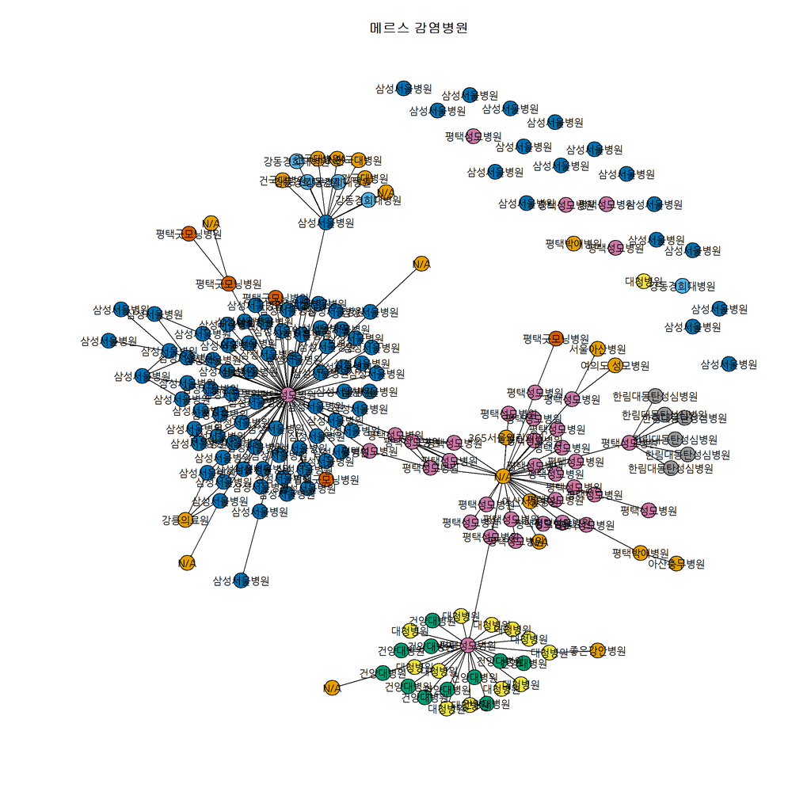

```r
# 5. 병원 시각화 ------
V(mers_ng)$color <- fct_lump(V(mers_ng)$감염병원, 7)

plot(mers_ng,
     vertex.label = V(mers_ng)$감염병원,
     vertex.label.color = "black",
     vertex.label.cex = 0.9,
     vertex.label.family="NanumGothic",
     edge.color = 'black',
     vertex.size = 5,
     edge.arrow.size = .05,
     main = "메르스 감염병원")
```

## 6. 인터랙티브 메르스 감염 시각화

동적(static), 정적(dynamic), 인터랙티브(interactive) 네트워크 시각화 팩키지가 다수 존재한다. R Base 그래픽 시스템에 기초한 계열과 최근 그래프 문법(grammar of graphcis)에 기초한 계열 이 정적그래프에 존재하고, 동적, 인터랙티브, 애니메이션 계열이 별도로 존재한다.

- 정적:
  - Base 그래프: **igraph**, statnet
  - 그래프 문법(grammar of graphcis): ggraph, ggnet, ggnetwork 등
- 동적: **threejs**, visNetwork, networkD3, visNetwork, sigma, rgexf 등

```r
graphjs(mers_ng,
        vertex.shape = V(mers_ng)$name,
        vertex.size = 0.1,
        edge.color = 'darkgray',
        main = "메르스 전파 네트워크"
)
```

[interactive chart not shown]

[^1]: [데이터저널리즘, 메르스 사태를 한눈에_KBS 성재호 기자](http://reportplus.kr/?p=15034)